# Ford GoBike System Data

## Preliminary Wrangling

> This data set includes information about individual rides made in a bike-sharing system covering the greater San Francisco Bay area.

```python
# import all packages and set plots to be embedded inline
import numpy as np
import pandas as pd
import matplotlib.pyplot as plt
import seaborn as sb

%matplotlib inline
```

```python
#Loading the data
df=pd.read_csv("201902-fordgobike-tripdata.csv")
df.head()
```

|  | duration_sec | start_time | end_time | start_station_id | start_station_name | start_station_latitude | start_station_longitude | end_station_id | end_station_name | end_station_latitude | end_station_longitude | bike_id | user_type | member_birth_year | member_gender | bike_share_for_all_trip |
| --- | --- | --- | --- | --- | --- | --- | --- | --- | --- | --- | --- | --- | --- | --- | --- | --- |
| 0 | 52185 | 2019-02-28 17:32:10.1450 | 2019-03-01 08:01:55.9750 | 21.0 | Montgomery St BART Station (Market St at 2nd St) | 37.789625 | -122.400811 | 13.0 | Commercial St at Montgomery St | 37.794231 | -122.402923 | 4902 | Customer | 1984.0 | Male | No |
| 1 | 42521 | 2019-02-28 18:53:21.7890 | 2019-03-01 06:42:03.0560 | 23.0 | The Embarcadero at Steuart St | 37.791464 | -122.391034 | 81.0 | Berry St at 4th St | 37.775880 | -122.393170 | 2535 | Customer | NaN | NaN | No |
| 2 | 61854 | 2019-02-28 12:13:13.2180 | 2019-03-01 05:24:08.1460 | 86.0 | Market St at Dolores St | 37.769305 | -122.426826 | 3.0 | Powell St BART Station (Market St at 4th St) | 37.786375 | -122.404904 | 5905 | Customer | 1972.0 | Male | No |
| 3 | 36490 | 2019-02-28 17:54:26.0100 | 2019-03-01 04:02:36.8420 | 375.0 | Grove St at Masonic Ave | 37.774836 | -122.446546 | 70.0 | Central Ave at Fell St | 37.773311 | -122.444293 | 6638 | Subscriber | 1989.0 | Other | No |
| 4 | 1585 | 2019-02-28 23:54:18.5490 | 2019-03-01 00:20:44.0740 | 7.0 | Frank H Ogawa Plaza | 37.804562 | -122.271738 | 222.0 | 10th Ave at E 15th St | 37.792714 | -122.248780 | 4898 | Subscriber | 1974.0 | Male | Yes |

```python
#define the size of df
df.shape
```

```
(183412, 16)
```

```python
#checking if there any duplicates
sum(df.duplicated())
```

```
0
```

```python
#make a copy df not to disturb the original data
df2 = df.copy()
```

```python
#count number of bikes in the system
df2.bike_id.nunique()
```

```
4646
```

```python
#count number of bikes in the system
df2.start_station_id.nunique()
```

```
329
```

```python
df2.user_type.unique()
```

```
array(['Customer', 'Subscriber'], dtype=object)
```

```python
#Removing unwanted columns from the dataset for better analysis
df2.drop(['start_station_latitude','start_station_longitude', 'end_station_latitude', 'end_station_longitude'], axis=1, inplace=True)
df2.head(2)
```

|  | duration_sec | start_time | end_time | start_station_id | start_station_name | end_station_id | end_station_name | bike_id | user_type | member_birth_year | member_gender | bike_share_for_all_trip |
| --- | --- | --- | --- | --- | --- | --- | --- | --- | --- | --- | --- | --- |
| 0 | 52185 | 2019-02-28 17:32:10.1450 | 2019-03-01 08:01:55.9750 | 21.0 | Montgomery St BART Station (Market St at 2nd St) | 13.0 | Commercial St at Montgomery St | 4902 | Customer | 1984.0 | Male | No |
| 1 | 42521 | 2019-02-28 18:53:21.7890 | 2019-03-01 06:42:03.0560 | 23.0 | The Embarcadero at Steuart St | 81.0 | Berry St at 4th St | 2535 | Customer | NaN | NaN | No |

```python
df2.info()
```

```
<class 'pandas.core.frame.DataFrame'>
RangeIndex: 183412 entries, 0 to 183411
Data columns (total 12 columns):
 #   Column                   Non-Null Count   Dtype
---  ------                   --------------   -----
 0   duration_sec             183412 non-null  int64
 1   start_time               183412 non-null  object
 2   end_time                 183412 non-null  object
 3   start_station_id         183215 non-null  float64
 4   start_station_name       183215 non-null  object
 5   end_station_id           183215 non-null  float64
 6   end_station_name         183215 non-null  object
 7   bike_id                  183412 non-null  int64
 8   user_type                183412 non-null  object
 9   member_birth_year        175147 non-null  float64
 10  member_gender            175147 non-null  object
 11  bike_share_for_all_trip  183412 non-null  object
dtypes: float64(3), int64(2), object(7)
memory usage: 16.8+ MB
```

### What is the structure of your dataset?

> The dataset records 183412 entries(trips). the system has 4646 bikes and 329 stations. There are some missing data in members' coloumns (gender and birthyear)

### What is/are the main feature(s) of interest in your dataset?

> When most trips are taken in terms of time of day, day of the week

> average trip time

> Does the above depend on user age / gender or if the user is a subscriber or customer or age?

> most visted stations

### What features in the dataset do you think will help support your investigation into your feature(s) of interest?

> start time(but first will be converted to time format)

> duration_sec (but will need to be converted into minutes)

> user_type , member_birth_year , member_gender

> start_station_id , end_station_id to define most repeated stations

```python
#convert time columns into datetime to can make aggregations
df2['start_time'] = pd.to_datetime(df['start_time'])
df2['end_time'] = pd.to_datetime(df['end_time'])
df2.info()
```

```
<class 'pandas.core.frame.DataFrame'>
RangeIndex: 183412 entries, 0 to 183411
Data columns (total 12 columns):
 #   Column                   Non-Null Count   Dtype
---  ------                   --------------   -----
 0   duration_sec             183412 non-null  int64
 1   start_time               183412 non-null  datetime64[ns]
 2   end_time                 183412 non-null  datetime64[ns]
 3   start_station_id         183215 non-null  float64
 4   start_station_name       183215 non-null  object
 5   end_station_id           183215 non-null  float64
 6   end_station_name         183215 non-null  object
 7   bike_id                  183412 non-null  int64
 8   user_type                183412 non-null  object
 9   member_birth_year        175147 non-null  float64
 10  member_gender            175147 non-null  object
 11  bike_share_for_all_trip  183412 non-null  object
dtypes: datetime64[ns](2), float64(3), int64(2), object(5)
memory usage: 16.8+ MB
```

```python
#converting duration into minutes to be more reasonable and easier in observations
df2["duration_min"]=(df2['duration_sec']/60).round(2)
df2.head(2)
```

|  | duration_sec | start_time | end_time | start_station_id | start_station_name | end_station_id | end_station_name | bike_id | user_type | member_birth_year | member_gender | bike_share_for_all_trip | duration_min |
| --- | --- | --- | --- | --- | --- | --- | --- | --- | --- | --- | --- | --- | --- |
| 0 | 52185 | 2019-02-28 17:32:10.145 | 2019-03-01 08:01:55.975 | 21.0 | Montgomery St BART Station (Market St at 2nd St) | 13.0 | Commercial St at Montgomery St | 4902 | Customer | 1984.0 | Male | No | 869.75 |
| 1 | 42521 | 2019-02-28 18:53:21.789 | 2019-03-01 06:42:03.056 | 23.0 | The Embarcadero at Steuart St | 81.0 | Berry St at 4th St | 2535 | Customer | NaN | NaN | No | 708.68 |

```python
#drop the rows with missing data
df2.dropna(axis=0,inplace=True)
```

```python
#calculate the users age
import datetime

df2['user_age']= datetime.datetime.now().year - df2['member_birth_year']
df2['user_age'].astype(int)
df2.head()
```

|  | duration_sec | start_time | end_time | start_station_id | start_station_name | end_station_id | end_station_name | bike_id | user_type | member_birth_year | member_gender | bike_share_for_all_trip | duration_min | user_age |
| --- | --- | --- | --- | --- | --- | --- | --- | --- | --- | --- | --- | --- | --- | --- |
| 0 | 52185 | 2019-02-28 17:32:10.145 | 2019-03-01 08:01:55.975 | 21.0 | Montgomery St BART Station (Market St at 2nd St) | 13.0 | Commercial St at Montgomery St | 4902 | Customer | 1984.0 | Male | No | 869.75 | 36.0 |
| 2 | 61854 | 2019-02-28 12:13:13.218 | 2019-03-01 05:24:08.146 | 86.0 | Market St at Dolores St | 3.0 | Powell St BART Station (Market St at 4th St) | 5905 | Customer | 1972.0 | Male | No | 1030.90 | 48.0 |
| 3 | 36490 | 2019-02-28 17:54:26.010 | 2019-03-01 04:02:36.842 | 375.0 | Grove St at Masonic Ave | 70.0 | Central Ave at Fell St | 6638 | Subscriber | 1989.0 | Other | No | 608.17 | 31.0 |
| 4 | 1585 | 2019-02-28 23:54:18.549 | 2019-03-01 00:20:44.074 | 7.0 | Frank H Ogawa Plaza | 222.0 | 10th Ave at E 15th St | 4898 | Subscriber | 1974.0 | Male | Yes | 26.42 | 46.0 |
| 5 | 1793 | 2019-02-28 23:49:58.632 | 2019-03-01 00:19:51.760 | 93.0 | 4th St at Mission Bay Blvd S | 323.0 | Broadway at Kearny | 5200 | Subscriber | 1959.0 | Male | No | 29.88 | 61.0 |

## Univariate Exploration

### Average rides time in minutes

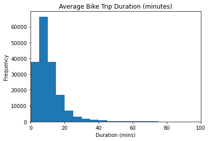

```python
bin_edges = np.arange(0, df2['duration_min'].max()+5 , 5)
plt.hist(data = df2 , x = 'duration_min' , bins = bin_edges);
plt.xlim(0,100);
plt.xlabel('Duration (mins)');
plt.ylabel("Frequency");
plt.title('Average Bike Trip Duration (minutes)');
```

```python
#to notice if there outliers or not
df2['duration_min'].head(50)
```

```
0      869.75
2     1030.90
3      608.17
4       26.42
5       29.88
6       19.12
7       26.92
8       26.17
9       17.48
10       7.63
11       8.43
12      19.60
14       6.58
15       3.47
16       9.13
```

[output cut: 36 more lines]

> Most rides durations are less than 20 mins specificaly around 10 mins. but there are exceptional rides exceeded 10 min and few that have between 40 and 80 mins

### Number of rides per day

```python
df2['day_of_week'] = pd.DatetimeIndex(df2['start_time']).weekday
df2.head(1)
```

|  | duration_sec | start_time | end_time | start_station_id | start_station_name | end_station_id | end_station_name | bike_id | user_type | member_birth_year | member_gender | bike_share_for_all_trip | duration_min | user_age | day_of_week |
| --- | --- | --- | --- | --- | --- | --- | --- | --- | --- | --- | --- | --- | --- | --- | --- |
| 0 | 52185 | 2019-02-28 17:32:10.145 | 2019-03-01 08:01:55.975 | 21.0 | Montgomery St BART Station (Market St at 2nd St) | 13.0 | Commercial St at Montgomery St | 4902 | Customer | 1984.0 | Male | No | 869.75 | 36.0 | 3 |

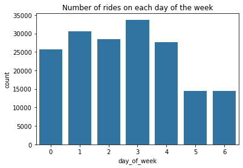

```python
base_color=sb.color_palette()[0]
sb.countplot(data = df2 , x = 'day_of_week' , color = base_color);
plt.title('Number of rides on each day of the week');
```

> Most rides happen on day(3) which is Thursday and less rides happen on days (5,6) which are Saturday and Sunday by mostly equal frequency

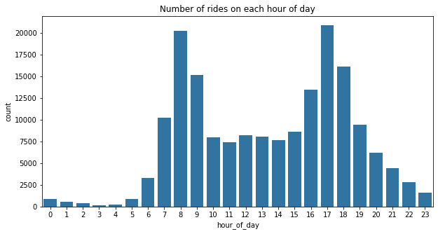

```python
#getting number of rides per hour during the days
df2['hour_of_day'] = pd.DatetimeIndex(df2['start_time']).hour
df2.head(1)
plt.figure(figsize=(10,5))
sb.countplot(data = df2 , x = 'hour_of_day' , color = base_color);
plt.title('Number of rides on each hour of day');
```

> Most rides happen in the morning and the evening, which makes sense beacuase these are the rush hours in the day

### Most visited stations

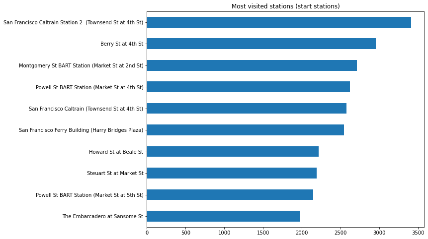

```python
plt.figure(figsize =(10,8))
top10 = df2.start_station_name.value_counts()[1:11].sort_values()
#plot the names on y axis
top10.plot(kind = 'barh')
plt.title('Most visited stations (start stations)');
```

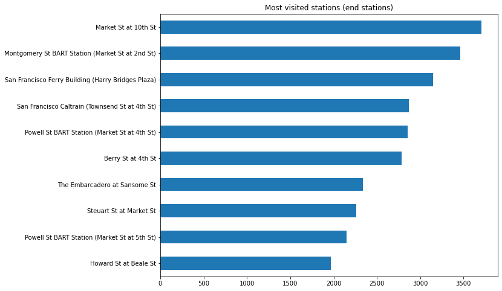

```python
plt.figure(figsize =(10,8))
top10 = df2.end_station_name.value_counts()[1:11].sort_values()
#plot the names on y axis
top10.plot(kind = 'barh')
plt.title('Most visited stations (end stations)');
```

### number of users per type

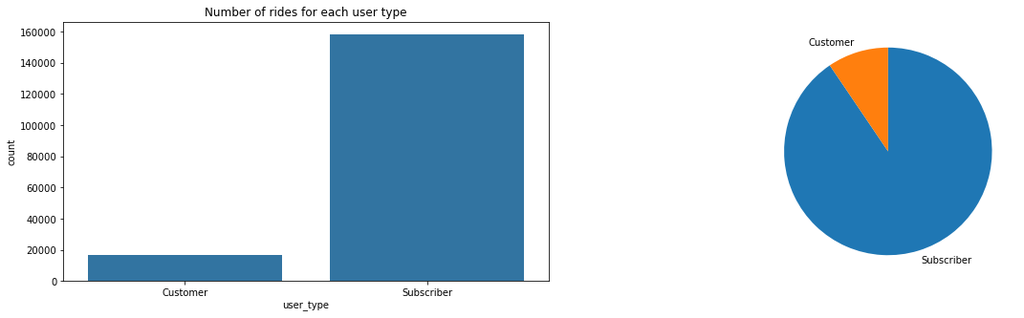

```python
# have two plots side-by-side
# Set a larger figure size for subplots
plt.figure(figsize = [20, 5])

plt.subplot(1, 2, 1) # 1 row, 2 cols, subplot 1
base_color = sb.color_palette()[0]
sb.countplot(data = df2 , x = 'user_type' , color = base_color);
plt.title('Number of rides for each user type');

plt.subplot(1, 2, 2) # 1 row, 2 cols, subplot 2
user_counts = df2['user_type'].value_counts()
plt.pie(user_counts, labels = user_counts.index, startangle = 90, counterclock = False);
```

> Number of subscribers is much more than customers so business wise may be we need to focus on the main users which are subscribers or we need to increase number of customers to earn more users

## Bivariate Exploration

### Observations about users

[figure not shown]

```python
#see if rides duration depends on gender

#bin_edges = np.arange(0, df2['duration_min'].max()+5 , 5)
#plt.hist(data = df2 , x = 'duration_min' , bins = bin_edges);
plt.figure(figsize=(12,8));
plt.xlim(0,100);
plt.title('Rides duration by gender')
sb.countplot(data = df2, x = 'duration_min', hue = 'member_gender');
```

[figure not shown]

```python
#see if number of rides depends on gender

plt.title('Number of rides by gender')
sb.countplot(data = df2, x = 'user_type', hue = 'member_gender');
```

> Male users are much more than females in both types customers and subscribers

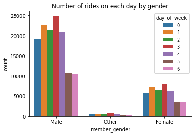

```python
#see if number of rides on different days depends on gender
plt.title('Number of rides on each day by gender')
sb.countplot(data = df2, x = 'member_gender', hue = 'day_of_week');
```

> Days of uasage don't differ much from males to females, Thursday still the most day with rides

```python
#ranging age

conditions = [
    (df2['user_age'] < 18),
    (df2['user_age'] >= 18) & (df2['user_age'] < 20 ),
    (df2['user_age'] >= 20) & (df2['user_age'] < 40 ),
    (df2['user_age'] >= 40) ]
choices = ['kids', 'teenagers', 'adults', "old"]
df2['age_range'] = np.select(conditions, choices, default='black')
df2.head()
```

|  | duration_sec | start_time | end_time | start_station_id | start_station_name | end_station_id | end_station_name | bike_id | user_type | member_birth_year | member_gender | bike_share_for_all_trip | duration_min | user_age | day_of_week | hour_of_day | age_range |
| --- | --- | --- | --- | --- | --- | --- | --- | --- | --- | --- | --- | --- | --- | --- | --- | --- | --- |
| 0 | 52185 | 2019-02-28 17:32:10.145 | 2019-03-01 08:01:55.975 | 21.0 | Montgomery St BART Station (Market St at 2nd St) | 13.0 | Commercial St at Montgomery St | 4902 | Customer | 1984.0 | Male | No | 869.75 | 36.0 | 3 | 17 | adults |
| 2 | 61854 | 2019-02-28 12:13:13.218 | 2019-03-01 05:24:08.146 | 86.0 | Market St at Dolores St | 3.0 | Powell St BART Station (Market St at 4th St) | 5905 | Customer | 1972.0 | Male | No | 1030.90 | 48.0 | 3 | 12 | old |
| 3 | 36490 | 2019-02-28 17:54:26.010 | 2019-03-01 04:02:36.842 | 375.0 | Grove St at Masonic Ave | 70.0 | Central Ave at Fell St | 6638 | Subscriber | 1989.0 | Other | No | 608.17 | 31.0 | 3 | 17 | adults |
| 4 | 1585 | 2019-02-28 23:54:18.549 | 2019-03-01 00:20:44.074 | 7.0 | Frank H Ogawa Plaza | 222.0 | 10th Ave at E 15th St | 4898 | Subscriber | 1974.0 | Male | Yes | 26.42 | 46.0 | 3 | 23 | old |
| 5 | 1793 | 2019-02-28 23:49:58.632 | 2019-03-01 00:19:51.760 | 93.0 | 4th St at Mission Bay Blvd S | 323.0 | Broadway at Kearny | 5200 | Subscriber | 1959.0 | Male | No | 29.88 | 61.0 | 3 | 23 | old |

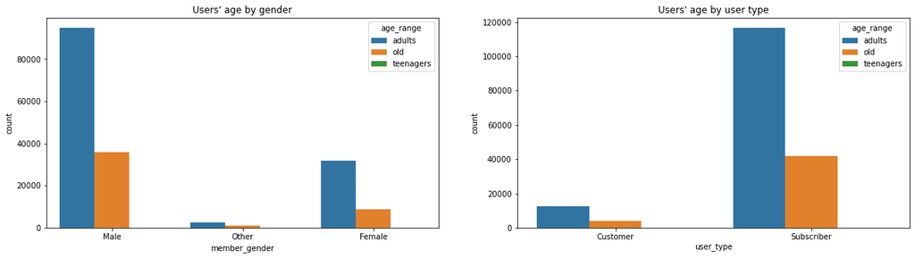

```python
#see which users segment (by age) uses the system the most

# have two plots side-by-side
# Set a larger figure size for subplots
plt.figure(figsize = [20, 5])

plt.subplot(1, 2, 1) # 1 row, 2 cols, subplot 1
sb.countplot(data = df2, x = 'member_gender', hue = 'age_range');
plt.title("Users' age by gender");

plt.subplot(1, 2, 2) # 1 row, 2 cols, subplot 2
sb.countplot(data = df2, x = 'user_type', hue = 'age_range');
plt.title("Users' age by user type");
```

> Adults between 20 and 40 years old are the main users

> old people > 40 years old are also a bid segment of users

## Multivariate Exploration

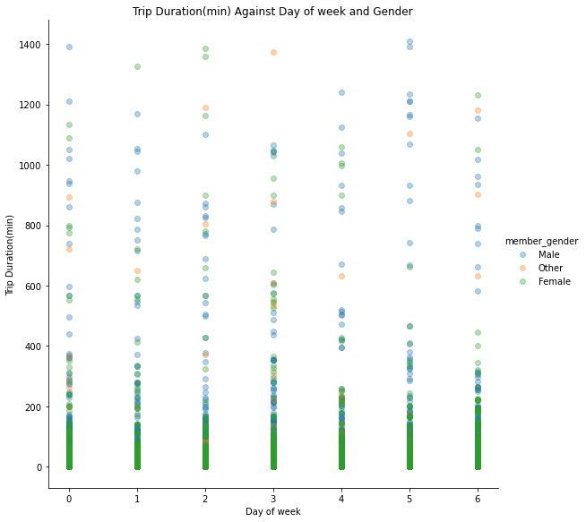

```python
# Finding out how the average trip time is affected by gender and day.
g = sb.FacetGrid(data =  df2, hue = 'member_gender', height = 8)
g.map(plt.scatter, 'day_of_week','duration_min', alpha = 1/3)
g.add_legend()
plt.title('Trip Duration(min) Against Day of week and Gender')
plt.xlabel('Day of week')
plt.ylabel('Trip Duration(min)');
```

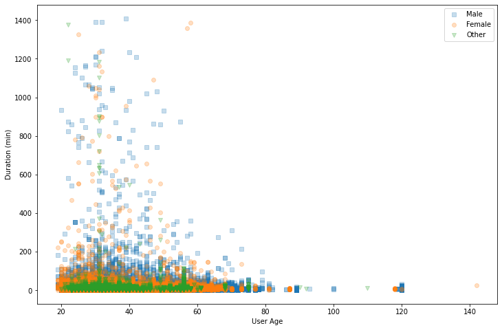

```python
# Finding out how the average trip time is affected by gender and age
gender_markers = [['Male', 's'],['Female', 'o'],['Other', 'v']]
plt.figure(figsize=(12,8));
for gender, marker in gender_markers:
    df_gender = df2[df2['member_gender'] == gender]
    plt.scatter((df_gender['user_age']), df_gender['duration_min'], marker = marker, alpha=0.25)
plt.legend(['Male','Female','Other']);
plt.xlabel('User Age');
plt.ylabel('Duration (min)');
plt.show();
```

> Younger users take longer rides as well as most of them are males